# AnniZhou_summary_report

@Summary of Anni Zhou's contributions

## Initializations

- Removing URLs from tweets
- Converting all tweets to lowercase
- Removing punctuations
- Removing stopwords

**Example:**

0 #DidYouKnow: @WFP is 100% voluntarily funded: ...

1 To treat COVID-19, administration expected to ...

2 To treat COVID-19, administration expected to ...

3 @MichiganDOT will not accept cash transactions...

4 @MichiganDOT will not accept cash transactions...

**Target:**

0 didyouknow wfp 100 voluntarily funded every ai...

1 treat administration expected relax physician ...

2 treat administration expected relax physician ...

3 michigandot accept cash transactions eastbound...

4 michigandot accept cash transactions eastbound...

[figure not shown]

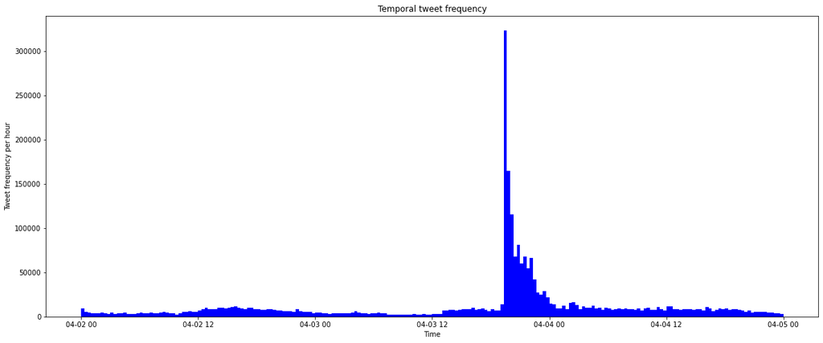